# Estimation of Growth Rates with package `growthrates`

Thomas Petzoldt

2015-08-07

# Introduction

The growth rate of a population is a direct measure of fitness. Therefore, determination of growth rates is common in many disciplines of theoretical and applied biology, e.g. physiology, ecology, eco-toxicology or pharmacology.

This package aims to streamline estimation of growth rates from direct or indirect measures of population density (e.g. cell counts, optical density or fluorescence) determined in batch experiments or field observations. It should be applicable to different species of bacteria, archaea, protists, and metazoa, e.g. *E. coli*, *Cyanobacteria*, *Paramecium*, green algae or *Daphnia*.

The determination of growth rates from chemostat and semi-continuous cultures is currently not covered by the package, but we are open to include it, depending on your interest and the availability of data.

# Methods

The package includes three types of methods:

- Nonlinear fitting of parametric growth models like the logistic or the Gompertz growth model. Parametric model fitting is done by using package `FME` (Flexible Modelling Environment) of Soetaert and Petzoldt (2010) . In addition to growth models given in closed form (i.e. empirical regression equations or analytical solution of differential equations) it is also possible to use numerically solved differential equation models. Such models are then solved with package `deSolve’ (Soetaert, Petzoldt, and Setzer 2010).
- Fitting of linear models to the period of exponential growth using the ``growth rates made easy method’’ of Hall and Barlow (2013) ,
- Nonparametric growthrate estimation by using smoothers. R contains several very powerful methods for this, that can leveraged for this purpose. The currently implemented method uses function `smooth.spline`, similar to the package `grofit` (Kahm et al. 2010).

The package contains methods to fit single data sets or complete series of data sets organized in a data frame. It contains also functions for extracting results (e.g. `coef`, `summary`, `deviance`, `obs`, `residuals`, `rsquared` and `results`) and methods for plotting (`plot`, `lines`). The implementation follows an object oriented style, so that the functions above determine automatically which method is used for a given class of objects.

## Data Set

The data set for demonstrating main features of the package was provided by Claudia Seiler from one of a series of plate reader experiments carried out at the Institute of Hydrobiology of TU Dresden. It describes growth of three different strains of bacteria (D=donor, R=recipient, T=transconjugant) in dependence of a gradient of the antibiotics Tetracycline.

```r
library("growthrates")
```

Firstly, we load the data and inspect its structure with `str`:

```r
data(bactgrowth)
str(bactgrowth)
```

```
## 'data.frame':    2232 obs. of  5 variables:
##  $ strain   : Factor w/ 3 levels "D","R","T": 3 3 3 3 3 3 3 3 3 3 ...
##  $ replicate: int  2 2 2 2 2 2 2 2 2 2 ...
##  $ conc     : num  0 0 0 0 0 0 0 0 0 0 ...
##  $ time     : int  0 1 2 3 4 5 6 7 8 9 ...
##  $ value    : num  0.013 0.014 0.017 0.022 0.03 0.039 0.042 0.045 0.048 0.049 ...
```

And we can also inspect the full data set with `View(growthrates)` or look at the first few lines with `head`:

```r
head(bactgrowth)
```

```
##   strain replicate conc time value
## 1      T         2    0    0 0.013
## 2      T         2    0    1 0.014
## 3      T         2    0    2 0.017
## 4      T         2    0    3 0.022
## 5      T         2    0    4 0.030
## 6      T         2    0    5 0.039
```

# Examples

## Inspect the Data

Plot raw data:

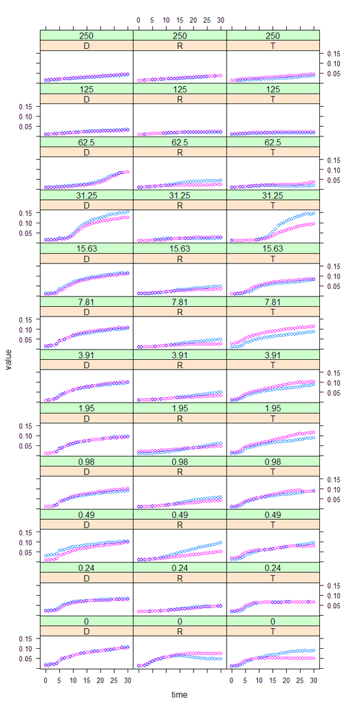

```r
library(lattice)
data(bactgrowth)
xyplot(value ~ time|strain+as.factor(conc), data=bactgrowth, groups = replicate)
```

## Fit Models to Individual Data Sets

Single data sets can be analysed with functions `fit_easylinear`, `fit_growthmodels` or `fit_splines`. As a prerequisite, single data sets containing only one treatment have to be extracted from a complete experiment, which can be done with function `multsiplit’. In the following example, the full data table is first split into a list of experiments according to a vector of criteria and then the first experiment is extracted:

### Easy Linear Method

```r
splitted.data <- multisplit(bactgrowth, c("strain", "conc", "replicate"))
dat <- splitted.data[[1]]
```

In the next step, model fitting is done, e.g. with the “easylinear” method:

```r
fit <- fit_easylinear(dat$time, dat$value)
```

This method fits segments of linear models to the log-transformed data and tries to find the maximum growth rate. Several functions exist to inspect the outcome of the model fit, e.g.

```r
summary(fit)
```

```
##
## Call:
## lm(formula = y ~ x)
##
## Residuals:
##        1        2        3        4        5        6
##  0.02113 -0.03716 -0.03727  0.04552  0.06376 -0.05598
##
## Coefficients:
##             Estimate Std. Error t value Pr(>|t|)
## (Intercept) -4.39425    0.06429  -68.35 2.74e-07 ***
## x            0.20490    0.01336   15.34 0.000105 ***
## ---
## Signif. codes:  0 '***' 0.001 '**' 0.01 '*' 0.05 '.' 0.1 ' ' 1
##
## Residual standard error: 0.05587 on 4 degrees of freedom
## Multiple R-squared:  0.9833, Adjusted R-squared:  0.9791
## F-statistic: 235.3 on 1 and 4 DF,  p-value: 0.0001053
```

```r
coef(fit)      # exponential growth parameters
```

```
##        y0        mu
## 0.0123482 0.2048985
```

```r
rsquared(fit)  # coefficient of determination (of log-transformed data)
```

```
##        r2
## 0.9832876
```

```r
deviance(fit)  # residual sum of squares of log-transformed data
```

```
## [1] 0.01248744
```

Plotting can then be done either in log-scale or after re-transformation

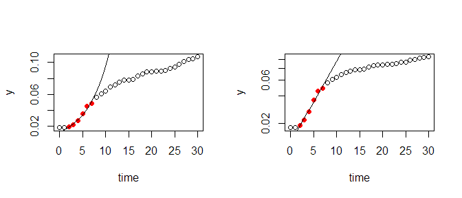

```r
par(mfrow=c(1,2))
plot(fit)
plot(fit, log="y")
```

and in addition to Hall and Barlow (2013) it is also possible to modify the default settings of the algorithm:

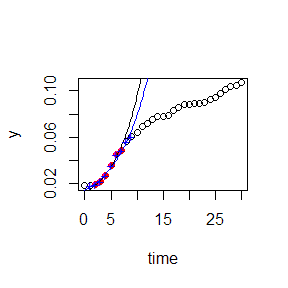

```r
fitx <- fit_easylinear(dat$time, dat$value, h=8, quota=0.95)
plot(fit)
lines(fitx, pch="+", col="blue")
```

## Parametric Nonlinear Growth Models

```r
p     <- c(y0=0.01, mu=0.03, K=0.1)
lower <- c(y0=1e-6, mu=0,   K=0)
upper <- c(y0=0.05, mu=5,   K=0.5)

fit1 <- fit_growthmodel(FUN=grow_logistic, p=p, dat$time, dat$value,
                        lower=lower, upper=upper)


p     <- c(yi=0.01, ya=0.01, kw=0.1,    mu=0.2, K=0.1)
lower <- c(yi=1e-6, ya=1e-6, kw=0,    mu=0,   K=0)
upper <- c(yi=0.05, ya=0.05, kw=10,   mu=5,   K=0.5)

fit2 <- fit_growthmodel(FUN=grow_twostep, p=p, time=dat$time, y=dat$value,
                        lower=lower, upper=upper)


coef(fit1)
```

```
##         y0         mu          K
## 0.01748232 0.20007383 0.09962556
```

```r
coef(fit2)
```

```
##          yi          ya          kw          mu           K
## 0.005965358 0.013603051 9.906225652 0.177871577 0.101896160
```

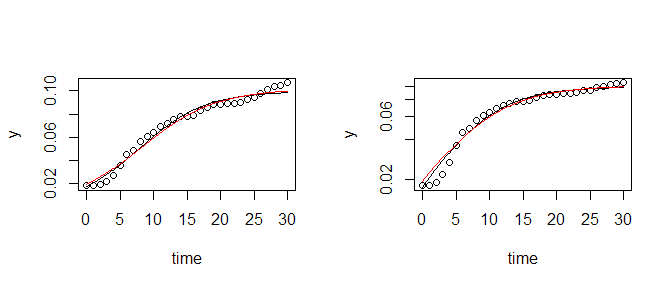

```r
par(mfrow=c(1,2))
plot(fit1)
lines(fit2, col="red")


plot(fit1, log="y")
lines(fit2, col="red")
```

## Nonparametric Smoothing Splines

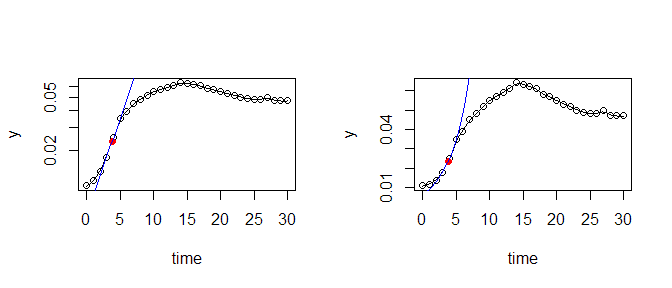

```r
dat <- splitted.data[[2]]
time <- dat$time
y    <- dat$value

## automatic smoothing with cv
res <- fit_spline(time, y)

par(mfrow=c(1,2))
plot(res, log="y")
plot(res)
```

```r
coef(res)
```

```
##          y0          mu
## 0.006562443 0.335991063
```

# Fit Multiple Data Sets

Fiting multiple data sets at once is possible with functions `all_easyliner`, `all_growthrates` and `alls_splines'. Usage is similar for all methods, whereas the parameters are analogous to the single-fit methods. Both, the easy growth rates and the smooting splines method are quite robust. In contrast to this, parametric fits with function`all_growthrates` need more care and more computational power.

Special emphasis should be given to the selection of good starting points. In addition, it is possible to select an alternative optimization algorithm, to enable additional output (`trace`) or to fine-tune their optimization control parameters. Nevertheless, it should be noted that parametric models have more explanatory power and may therefore be advantageous for basic research.

Nonlinear optimization is done with parallelized code, so multi-core computers can speed up computation.

It can be a good idea, to use a nonparametric approach like the smoothing spline method to get a first impression and, potentially, to derive start parameters for a parametric model.

In the following, we show an example with the smoothing spline method:

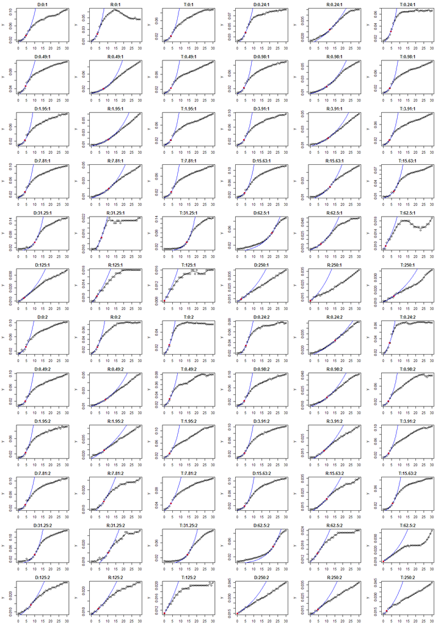

```r
many_fits <- all_splines(bactgrowth,
                  criteria=c("strain", "conc", "replicate"), spar=0.5)

par(mfrow=c(12,6))
par(mar=c(2.5,4,2,1))
plot(many_fits)
```

# Finally

Dependency of growth rate on antibiotic concentration for the three strains:

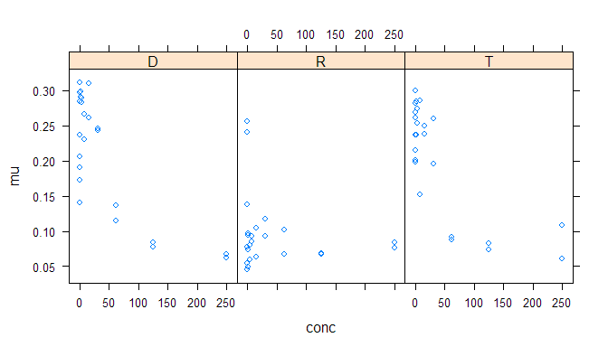

```r
many_res <- results(many_fits)
xyplot(mu ~ conc|strain, data=many_res)
```

# Acknowledgments

Many thanks to Claudia Seiler for the data set. Many thanks to the R Core Team (R Core Team 2015) for developing and maintaining **R**. This documentation was written using **knitr** (Xie 2014) and **rmarkdown** (Allaire et al. 2015).

References

Allaire, JJ, Joe Cheng, Yihui Xie, Jonathan McPherson, Winston Chang, Jeff Allen, Hadley Wickham, and Rob Hyndman. 2015. *Rmarkdown: Dynamic Documents for R*. http://CRAN.R-project.org/package=rmarkdown.

Hall, Acar, B. G., and M. Barlow. 2013. “Growth Rates Made Easy.” *Mol. Biol. Evol.* 31: 232–38. doi:10.1093/molbev/mst197.

Kahm, Matthias, Guido Hasenbrink, Hella Lichtenberg-Frate, Jost Ludwig, and Maik Kschischo. 2010. “Grofit: Fitting Biological Growth Curves with R.” *Journal of Statistical Software* 33 (7): 1–21. http://www.jstatsoft.org/v33/i07.

R Core Team. 2015. *R: A Language and Environment for Statistical Computing*. Vienna, Austria: R Foundation for Statistical Computing. http://www.R-project.org/.

Soetaert, Karline, and Thomas Petzoldt. 2010. “Inverse Modelling, Sensitivity and Monte Carlo Analysis in R Using Package FME.” *Journal of Statistical Software* 33 (3): 1–28. http://www.jstatsoft.org/v33/i03/.

Soetaert, Karline, Thomas Petzoldt, and R. Woodrow Setzer. 2010. “Solving Differential Equations in R: Package DeSolve.” *Journal of Statistical Software* 33 (9): 1–25. http://www.jstatsoft.org/v33/i09.

Xie, Yihui. 2014. “Knitr: A Comprehensive Tool for Reproducible Research in R.” In *Implementing Reproducible Computational Research*, edited by Victoria Stodden, Friedrich Leisch, and Roger D. Peng. Chapman; Hall/CRC. http://www.crcpress.com/product/isbn/9781466561595.